This tutorial is automatically generated from the file test/python/cell_based/tutorials/TestSpheroidTutorial.py.

```python
# Jupyter notebook specific imports
import matplotlib as mpl
import matplotlib.pyplot as plt
%matplotlib inline
```

# Introduction

This tutorial is an example of modelling spheroid growth with a nutrient. It covers:

```python
import chaste.core
chaste.init()
import chaste.cell_based
import chaste.mesh
import chaste.pde
import chaste.visualization
```

## Test 1 - a 2D mesh-based spheroid

In this test we set up a spheroid with a plentiful supply of oxygen on the boundary and watch it grow over time. Cells can gradually become apoptotic if the oxygen tension is too low.

```python
# Set up the test
chaste.cell_based.SetupNotebookTest()
```

```python
file_handler = chaste.core.OutputFileHandler("Python/TestSpheroidTutorial")
generator = chaste.mesh.HoneycombMeshGenerator(5, 5)
mesh = generator.GetMesh()
```

We create some cells next, with a stem-like proliferative type. This means they will continually proliferate if there is enough oxygen, similar to how a tumour spheroid may behave.

```python
cells = chaste.cell_based.VecCellPtr()
stem_type = chaste.cell_based.StemCellProliferativeType()
cell_generator = chaste.cell_based.CellsGeneratorSimpleOxygenBasedCellCycleModel_2()
cell_generator.GenerateBasicRandom(cells, mesh.GetNumNodes(), stem_type)
```

Define when cells become apoptotic for eachCell in cells:

```python
for eachCell in cells:
    eachCell.GetCellData().SetItem("oxygen", 30.0)
    cell_cycle_model = eachCell.GetCellCycleModel()
    cell_cycle_model.SetDimension(2)
    cell_cycle_model.SetStemCellG1Duration(4.0);
    cell_cycle_model.SetHypoxicConcentration(0.1);
    cell_cycle_model.SetQuiescentConcentration(0.3);
    cell_cycle_model.SetCriticalHypoxicDuration(8);
    birth_time = -chaste.core.RandomNumberGenerator.Instance().ranf() * (cell_cycle_model.GetStemCellG1Duration() +
                                                                         cell_cycle_model.GetSG2MDuration())
    eachCell.SetBirthTime(birth_time);
```

Now we have a mesh and a set of cells to go with it, we can create a `CellPopulation` as before.

```python
cell_population = chaste.cell_based.MeshBasedCellPopulation2_2(mesh, cells)
```

To view the results of this and the next test in Paraview it is necessary to explicitly generate the required .vtu files.

```python
cell_population.AddPopulationWriterVoronoiDataWriter()
```

PyChaste can do simple 3D rendering with VTK. We set up a VtkScene so that we can see the population evovle in real time.

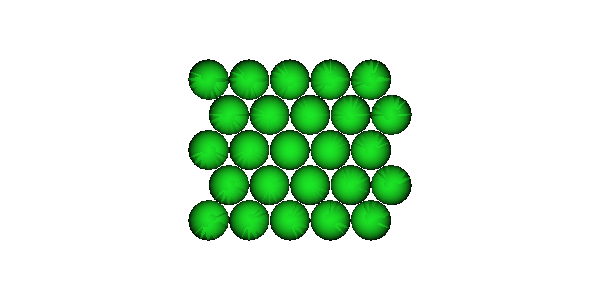

```python
scene= chaste.visualization.VtkScene2()
scene.SetCellPopulation(cell_population)
scene.GetCellPopulationActorGenerator().SetShowCellCentres(True)
scene.GetCellPopulationActorGenerator().SetShowVoronoiMeshEdges(False)
scene.GetCellPopulationActorGenerator().SetColorByCellData(True)
scene.GetCellPopulationActorGenerator().SetDataLabel("oxygen")
nb_manager = chaste.visualization.JupyterNotebookManager()
nb_manager.vtk_show(scene, width=600)
```

We then pass in the cell population into an `OffLatticeSimulation`, and set the output directory and end time.

```python
simulator = chaste.cell_based.OffLatticeSimulation2_2(cell_population)
simulator.SetOutputDirectory("Python/TestSpheroidTutorial")
simulator.SetEndTime(5.0)
```

We ask for output every 12 increments

```python
simulator.SetSamplingTimestepMultiple(12)
```

We define how the springs between cells behave using a force law.

```python
force = chaste.cell_based.GeneralisedLinearSpringForce2_2()
simulator.AddForce(force)
```

```python
pde = chaste.cell_based.CellwiseSourceEllipticPde2(cell_population, -0.5)
```

We set a constant amount of oxygen on the edge of the spheroid

```python
bc = chaste.pde.ConstBoundaryCondition2(1.0)
is_neumann_bc = False
```

Set up a pde modifier to solve the PDE at each simulation time step

```python
pde_modifier = chaste.cell_based.EllipticGrowingDomainPdeModifier2(pde,bc, is_neumann_bc)
pde_modifier.SetDependentVariableName("oxygen")
simulator.AddSimulationModifier(pde_modifier)
```

As before, we set up a scene modifier for real-time visualization

```python
scene_modifier = chaste.visualization.JupyterSceneModifier2(nb_manager)
scene_modifier.SetVtkScene(scene)
scene_modifier.SetUpdateFrequency(10)
simulator.AddSimulationModifier(scene_modifier)
```

Eventually remove apoptotic cells

```python
killer = chaste.cell_based.ApoptoticCellKiller2(cell_population)
simulator.AddCellKiller(killer)
```

To run the simulation, we call `Solve()`. We can again do a quick rendering of the population at the end of the simulation scene.Start()

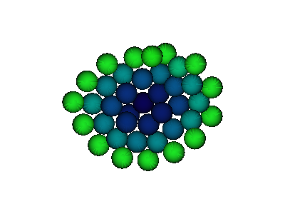

```python
scene.Start()
simulator.Solve()

# Tear down the test
chaste.cell_based.TearDownNotebookTest()
```

Full results can be visualized in Paraview from the `file_handler.GetOutputDirectoryFullPath()` directory.